## PT-Meta Table

Our Plot Designation

Full Plot Name

Plot Description

Primary Literature

Image

Aluminosilicates

Aluminosilicates phase diagram

NA

NA

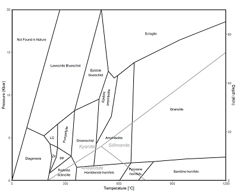

Intrusion Model

Intrusion Model pathway

NA

NA

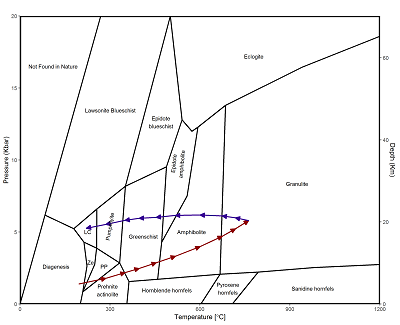

Collision Model

Collision Model pathway

NA

NA

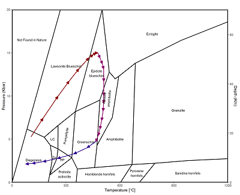

Invert Y axis

Invert Y axis

NA

NA

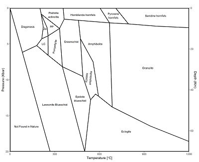

10 degree/km Geothermal Gradient

10 degree/km Geothermal Gradient

NA

NA

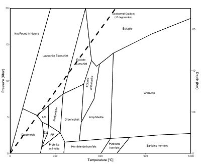

20 degree/km Geothermal Gradient

20 degree/km Geothermal Gradient

NA

NA

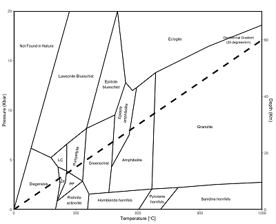

30 degree/km Geothermal Gradient

30 degree/km Geothermal Gradient

NA

NA

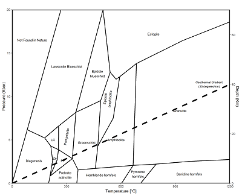

Wet Granite Solidus

Wet Granite Solidus

NA

NA

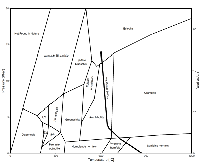

Annite + Quartz + 1/2 O2 and K-Spar + Magnetite + H2O

Annite + Quartz + 1/2 O2 and K-Spar + Magnetite + H2O mineral phase boundary

NA

NA

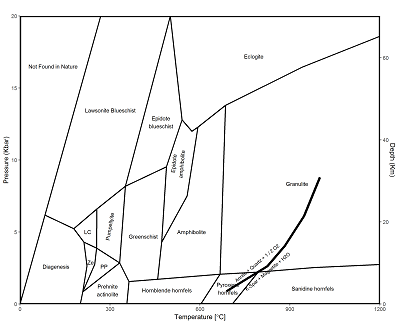

Phlogopite + Quartz and Melt + Orthopyroxene

Phlogopite + Quartz and Melt + Orthopyroxene mineral phase boundary

NA

NA

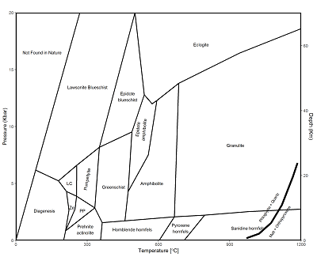

Anhydrous Minimum Melting Temperature

Anhydrous Minimum Melting Temperature

NA

NA

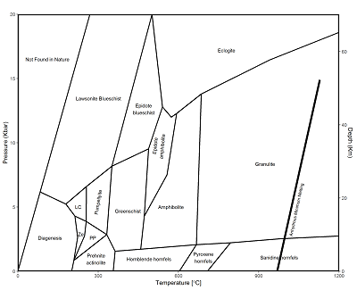

Biotite + Sillimanite and Codierite + K-Spar

Biotite + Sillimanite and Codierite + K-Spar mineral phase boundary

NA

NA

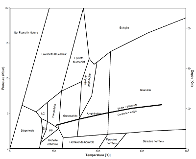

Aragonite and Calcite

Aragonite and Calcite mineral phase boundary

NA

NA

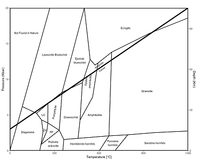

Muscovite + Quartz and Al2SiO5 + KAlSi3O8 + H2O

Muscovite + Quartz and Al2SiO5 + KAlSi3O8 + H2O mineral phase boundary

NA

NA

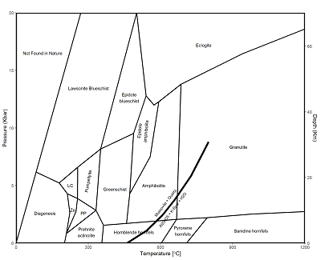